# Forecasting dry Spells in Malawi

By Centre for Humanitarian Data

2021-04-23

## Background

This document summaries the data work that has been done to correlate the occurence of a dry spell with different climatological indicators. This work has been done for OCHA’s Anticipatory Action pilot in Malawi related to dry spells. It explores the relations with seasonal observed indicators, the skill of short-term forecast to predict these dry spells, and the ability to observe dry spells in almost real-time. All work presented here has been done by the Centre for Humanitarian Data, but with indispensable help from technical partners. All the code is openly available [here](https://github.com/OCHA-DAP/pa-anticipatory-action), and will regularly be referred to in this document.

This work uses a list of historical dry spells and rainy seasons, that was also created as part of this project. Further information and analyses of the detection of these historical dry spells can be found [here](https://github.com/OCHA-DAP/pa-anticipatory-action/blob/develop/analyses/malawi/notebooks/historical_dry_spells_description_mean.html)

## Correlation of dry spells and seasonal indicators

Optimally the pre-alert of the trigger could be based on indicators with a long lead time, preferable 3 to 6 months. This would give the possibility of a wider range of anticipatory actions to be implemented by the organizations in country. Most information provided with such a long lead time doesn’t report directly the probability of dry spells in a certain location. They report a more general pattern, such as the ENSO state or the total precipitation over a 3 month period. Therefore, we explored whether these more broad properties that are forecasted well-ahead of the rainy season, do have a correlation with the occurrence of a dry spell. This analysis is thus solely looking at **observational** data, not at forecasts. If the correlations between these observed data sources turn out to be significant, we move to forecasts. This with the assumption that if there is no such correlation in the observed data, there won’t be any in the forecasted data.

### Previous work

The body of literature on the relation between long-term meteorological indicators and the occurence of dry spells in Malawi is rather limited. We are aware of two articles who investigated the correlation of dry spells in Malawi with ENSO, and 3-monthly precipitation, as well as temperature, wind speed, and wind direction. Mittal et al. (2021) investigated the correlation with total precipitation in a 3-month period and the occurrence of a prolonged dry spell in Malawi. This work defines a dry spell as 14 consecutive dry days, where a dry day is a day with <=2mm of precipitation. They found that there was only a weak correlation between the occurrence of a dry spell and the total 3-monthly precipitation, where again the strength of the correlation heavily depended on the location. Streefkerk (2020) looked at the correlation between 5-day long dry spells and the meteorological indicators of temperature, wind speed, wind direction and ENSO strength. It should be noted that 5-day long dry spells is a significantly different phenomenon than 14-day long dry spells, and thus results might not be transferable. She showed that the chosen indicators do have some predictive value for the occurrence of the 5-day dry spells, while these correlations heavily depend on the location. Moreover, the analysis suggests that the while the ENSO phenomenon has predictive value for overall drought, it is less decisive for the occurrence of dry spells, as these are more local events.

### ENSO state

A commonly used long-term meteorological indicator is the El Niño Southern Oscillation (ENSO) state. This state is a global phenomenon, that causes seasonal climatological fluctuations and is related to Sea Surface Temperatures (SSTs). More background on the ENSO phenomenon can be found [here](https://iri.columbia.edu/our-expertise/climate/enso/). Our analysis explores the correlation with the observed ENSO state and the occurence of a prolonged dry spell.

Several different indicators exist to measure the ENSO state, of which most are indicated [here](https://www.psl.noaa.gov/enso/dashboard.html). The two indicators most commonly used are the NINO3.4 index and ONI. They use slightly different sources of data and aggregation methodologies, but show similar historical patterns. For our analysis it was chosen to use ONI, as their data is commonly used to keep track of the current ENSO state.

#### Data source

[ONI](https://origin.cpc.ncep.noaa.gov/products/analysis_monitoring/ensostuff/ONI_v5.php) is reported as a running mean over a 3-month period. Open data exists from 1950 till present. Warm periods are defined as an ONI larger or equal to 0.5, while cold periods are defined as an ONI smaller or equal to -0.5. If 5 or more consecutive overlapping periods reach the threshold for a warm period, these seasons are defined as experiencing El Niño state. As you might guessed, 5 or more consecutive overlapping periods that reach the threshold for a cold period, are defined as experiencing La Niña state. All other seasons are defined as the neutral state.

#### Analysis

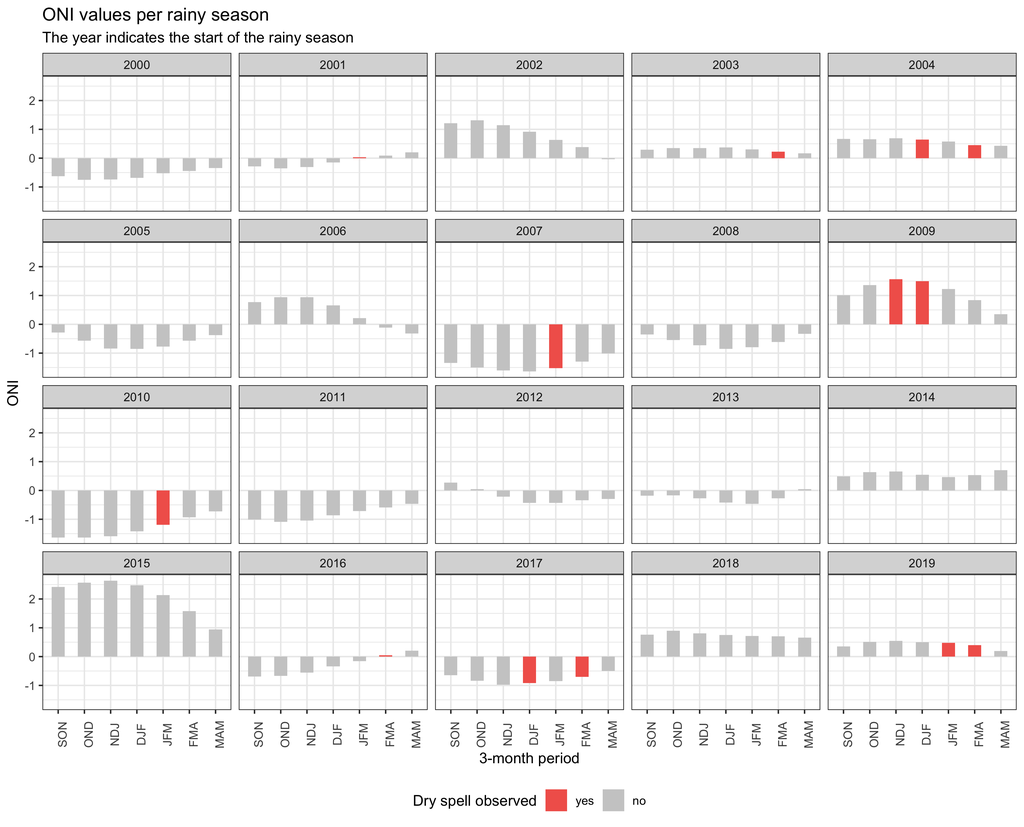

historical oni values dry spell

#### Forecasts

Due to not seeing a relationship between observed ENSO state and dry spells, we didn’t move on to analyze the forecasts with the assumption that this relationship will only be weaker. For those interested in the forecasts, the most commonly used forecasts is the one [produced by IRI](https://iri.columbia.edu/our-expertise/climate/forecasts/enso/current/), of which the [historical data](https://iri.columbia.edu/~forecast/ensofcst/Data/) can also be downloaded.

### Seasonal precipitation

Another commonly used forecast source with a long lead time are the so-called seasonal forecasts. Here a season is defined as a 3 month period. Seasonal precipitation forecasts are an often used product for informing predictions related to seasonal drought, and depending on the source include forecasts for 1 to 6 months ahead.

Some organizations also provide absolute forecasted amounts, either as an expected amount per day or per month. The main organizations providing this data are ECMWF and the UK Met office. From the daily projected amounts, one could in theory directly forecast the occurrence of a dry spell. However, since those forecasts have such a large uncertainty, it is very unlikely that the forecast will predict the occurrence of a dry spell by calendar day. Nevertheless, you can come up with other aggregated measures that might correlate with the occurrence of a dry spell. In this analysis we investigated the relationship of dry spells with total monthly and total seasonal precipitation.

#### Data source

CHIRPS was used as data source to compute the monthly and 3-monthly total precipitation, and the occurrences of 3-monthly below-average precipitation. CHIRPS was chosen as data source, since this is the same source as was used to detect observed dry spells and thus thereby we eliminate any weakening of relationship due to biases in different sources. See for more information about CHIRPS the section on defining observed dry spells.

#### Methodology

For the aggregation to admin2 level, we used a percentage-based approach since whether a raster cell had below-average precipitation is a binary variable, and thus taking the mean would not be approriate here. We therefore classified an admin2 having observed below-average precipitaiton if at least 50% of the raster cells received below-average precipitation

A 3-month period was assigned as having experienced a dry spell if a dry spell started during any of the 3 months in the given admin2.

#### Seasonal below-average precipitation

Below the confusion matrix is shown, which indicates the co-occurence of dry spells and below-average precipitation. As can be seen this co-occurence is not great. Only 55% (52/94) of the seasons with a dry spell also had below-average precipitation. Moreover, there were many 3-month periods with below-average precipitation but during which no dry spell occured. To be more precise this was the case in 89% of the below-average periods. Further analysis was done to determine if better correlations occur in certain admin2’s or during specific periods. This analysis didn’t show a significantly stronger signal, but for the curiously-minded the full analysis can be found here.

Based on this confusion matrix and the other analyses, we conclude that the occurence of below-average precipitation is not a good indicator for the likelihood of a dry spell occuring. We therefore didn’t move on to analyze the performance of seasonal forecasts instead of observations.

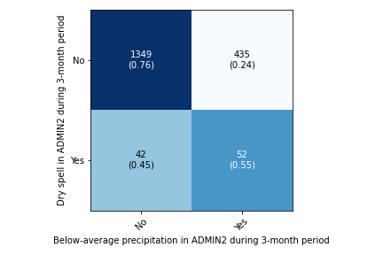

seasonal below average precipitation confusion matrix

#### Total seasonal precipitation

As we saw dry spells are more extreme than below-average precipitaiton. Therefore, a better correlation might be found if we define a threshold ourselves of the maximum precipitation (in mm) instead. We investigated different thresholds and the ability to detect dry spells. By solely looking at the distribution, grouped by the occurence of a dry spell, we can see that

1. Seasons with a dry spell do on average have less seasonal precipitation, where almost all seasons with a dry spell didn’t receive more than 800mms of rains.
2. Many seasons with no dry spell also have precipitation in the same range as those seasons with a dry spell. It will therefore be difficult to distinguish those.

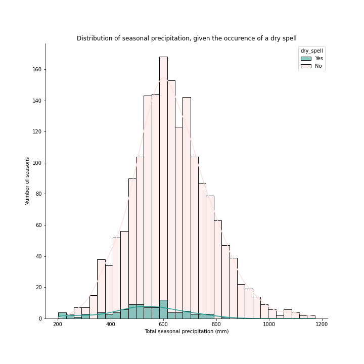

seasonal total precipitation distribution

#### Total monthly precipitation

[figure not shown]

monthly total precipitation distribution

#### Future

Number of dry days during a month

## Forecasting of dry spells

#### Previous work

We are not aware of any work attempting to forecast prolonged dry spells in Malawi. Moving away from Malawi, Gbangou et al. (2020) researched the predictability of dry spells in Ghana. They analyze how well the forecasts can predict the number of dry spells within a season, where a dry spell is defined as at least 5 consecutive days with less than 1mm of rainfall per day. Moreover, they try to forecast the length of the longest dry spell. For the forecasting, ECMWF’s seasonal forecast as well as a statistical model based on Sea Surface Temperatures (SST) is used. They show that skill of these two forecasts depend on the lead time and location. However, the found correlations are generally weak. Interestingly, the forecasts do show to be better at predicting the extreme years, though the correlations are still not strong. Nevertheless, they argue that the forecasts have better skill than guessing based on climatologies and thus can be used to inform actions. Similar work has been done by Surmaini et al. (2021), but focusing on Indonesia and using NOAA’s CFSv2 seasonal forecast model. They showed a bit higher correlations, again also showing that these correlations heavily depend on location. Due to a completely different climate, these results are not directly transferable to Malawi.

#### The data

Several organizations produce forecasts with a 15-day lead time, but most of them are not openly available. For this analysis, we used CHIRPS-GEFS. This is a forecast produced by GEFS, and bias-corrected to the CHIRPS data. This forecast was chosen because it is openly available, has a long historical record, is well-acknowledged, and is bias-corrected to the same data that was used to determine observed dry spells. CHIRPS-GEFS is available as raster data at 0.05 resolution. A forecast is produced each day, and these forecasts are available from 2000 till present, with a data gap in 2020. Each forecast indicates the projected cumulative precipitation during the next 15 days per raster cell.

#### Bias of CHIRPS-GEFS

We first analyzed the general performance of CHIRPS-GEFS, by computing a bias plot. This plot shows the observed precipitation over 15 days per admin2, retrieved from CHIRPS data, and on the y-axis the forecasted minus observed 15-day precipitation. If the forecast would be perfect, all values would form a horizontal line on the x-axis. However, from this plot we can see that CHIRPS-GEFS has the tendency to overpredict low amount of rainfall, while underpredicting high amounts of rainfall. Since we are interested in extremely low amounts of rainfall, this fact can be problematic for the forecasting skill of dry spells.

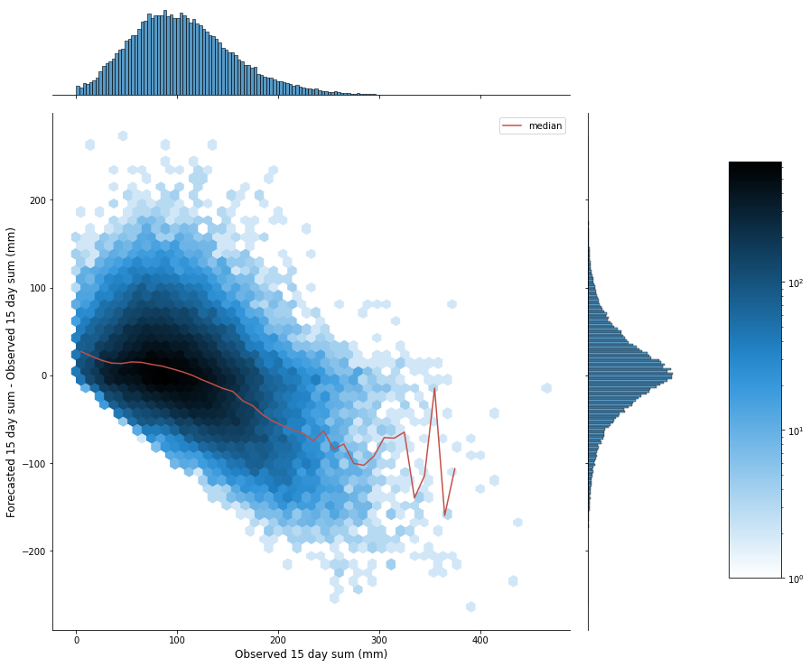

bias chirps gefs

## Real-time observation of dry spells

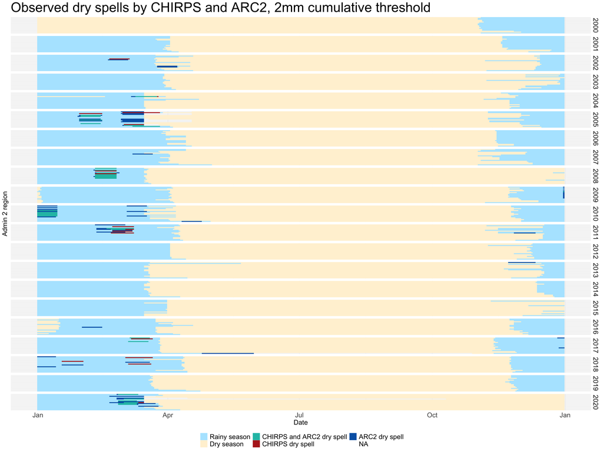

chirps vs arc2

## References

Gbangou, Talardia, Fulco Ludwig, Erik van Slobbe, Wouter Greuell, and Gordana Kranjac-Berisavljevic. 2020. “Rainfall and Dry Spell Occurrence in Ghana: Trends and Seasonal Predictions with a Dynamical and a Statistical Model.” *Theoretical and Applied Climatology* 141 (1): 371–87.

Mittal, Neha, Edward Pope, Stephen Whitfield, James Bacon, Marta Bruno Soares, Andrew J Dougill, Marc van den Homberg, et al. 2021. “Co-Designing Indices for Tailored Seasonal Climate Forecasts in Malawi.” *Frontiers in Climate* 2: 30.

Streefkerk, Ileen. 2020. “Linking Drought Forecast Information to Smallholder Farmer’s Agricultural Strategies and Local Knowledge in Southern Malawi.”

Surmaini, E, E Susanti, MR Syahputra, FR Fajary, and others. 2021. “Use of the Dry-Spell Seasonal Forecast in Crop Management Decisions.” In *IOP Conference Series: Earth and Environmental Science*, 648:012092. 1. IOP Publishing.